# R Notebook

## Things I did in class on Friday, September 1.

### The four functions

As I mentioned in class, every probability distribution in R comes with 4 functions. In the case of the binomial distribution, they are:

1. `rbinom` – draws random samples
2. `dbinom` – computes the probability distribution
3. `pbinom` – gives the cumulative distribution
4. `qbinom` – gives the quantile function

**Examples**

1. Suppose that the probability of heads is .3 and we flip a coin 15 times. What’s the chance of getting 6 heads?

```r
p<-dbinom(6,15,.3)
cat("The chance is ",p)
```

```
The chance is  0.147236
```

2. Let’s find the probabilities of each number of heads.

```r
xs<-seq(0,10) # x holds 0,1,...,10
fs<-dbinom(x,10,.3)
print(fs)
```

```
 [1] 0.0282475249 0.1210608210 0.2334744405
 [4] 0.2668279320 0.2001209490 0.1029193452
 [7] 0.0367569090 0.0090016920 0.0014467005
[10] 0.0001377810 0.0000059049
```

3. Let’s plot this. We’ll use ggplot. This is a very simple use of ggplot to make a bar chart. We’ll talk about ggplot more comprehensively later. For now, you can use this as a “black box”. In the part that says `aes(x=?,y=?)` you put the data for the x and y coordinates. The `scale_x_continous(break=?)` says where to put the x-ticks. The `xlab("?")` labels the x-axis. The `ylab` labels the y-axis.

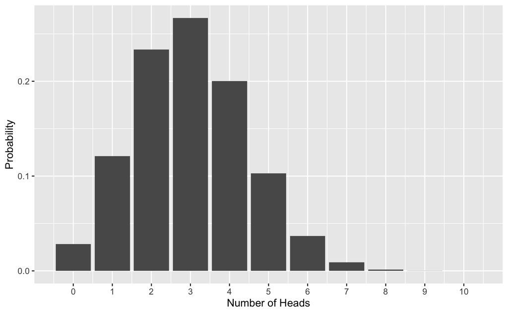

```r
ggplot()+geom_col(aes(x=xs,y=fs))+scale_x_continuous(breaks=seq(0,10))+xlab("Number of Heads")+ylab("Probability")
```

4. Let’s sample this distribution. We’ll flip a coin with p=.3 10 times, and we’ll repeat this experiment 100 times, counting how many heads we get each repetition.

```r
heads <- rbinom(100,10,.3)
heads
```

```
  [1] 1 4 6 3 3 1 3 4 4 5 1 6 4 5 1 5 3 2 1 3 2 2 3 3
 [25] 4 2 0 3 1 3 4 2 3 3 3 5 2 4 2 4 2 3 2 2 1 5 0 3
 [49] 3 2 2 1 2 4 2 3 4 5 2 2 1 4 0 4 2 3 4 1 2 1 2 2
 [73] 4 2 2 3 3 3 2 3 6 4 2 2 3 4 3 5 2 2 1 3 5 2 4 4
 [97] 5 4 2 3
```

Now let’s make a histogram. Again, here is a “black box” command for ggplot. Again, you put the data in `aes(x=?)` and you put the location for the x-ticks in `scale_x_continous(breaks=?)`.

```r
ggplot()+geom_histogram(aes(x=heads),stat='count')+scale_x_continuous(breaks=seq(0,10))+xlab("Number of Heads")+ylab("Count")
```

[output not shown]

```r
chance<-pbinom(40,80,.3)-pbinom(19,80,.3)
cat("Chance  of between 40 and 20 inclusive is ",chance)
```

```
Chance  of between 40 and 20 inclusive is  0.86472
```

6. Among the number of heads in 100 flips of a coin with .3, what’s the 25th percentile for the number of heads? That’s what `qbinom` is for.

```r
twentyFifth<-qbinom(.25,100,.3)
paste("The 25th percentile is ",twentyFifth)
```

```
[1] "The 25th percentile is  27"
```

Let’s check.

```r
check<-pbinom(twentyFifth,100,.3)
check
```

```
[1] 0.2963662
```

7. An experiment

Let’s sample from the binomial 10000 times and look at the 25th percentile.

```r
data<-rbinom(10000,100,.3)
t1<-sum(data<twentyFifth)
t2<-sum(data<twentyFifth+1)
cat("Number less than ",twentyFifth, "is ",t1,"\n")
cat("Number less than ",twentyFifth+1,"is",t2)
```

[output not shown]

## Practice

1. Let X be a binomial random variable with n=50 and p=.7.
1. Draw 1000 samples from X. How many of your sampled values are less than 30?
2. Based on the probability distribution, how many sampled values would you expect to see that are less than 30?
3. Plot a histogram of your sampled values.
2. The poisson distribution is a discrete probability distribution that arises in queuing theory (and many other places). For example, imagine that customers arrive at a server at a rate so that, in a typical one hour period, 20 customers come. But the intervals between customers are random and independent of one another. Then in a randomly chosen hour, the probability of k customers arriving is `dpois(k,20)`.
1. Sample this distribution 1000 times (hint: use `rpois`). What is the largest number of people who arrive in an one of these random hours? What is the smallest?
2. Suppose you want to design your system so that it can handle the number of arriving customers 95% of the time. How many people should you design for? (Hint: use `qpois`).
3. What’s the chance that between 18 and 22 people arrive in a given hour? (Hint: use `ppois`).
4. Plot the Poisson distribution probabilities. (Hint: use `dpois`).